# Introduction to R

#### Exercise

Colour the volcanoplot using two different colours of your choice. You can use one of the palettes or type `colours()` to see what colours are available. Choose two nice colours or two ugly ones.

We could colour our significant genes that are downregulated and the genes that are upregulated using separate colours, by changing our signif column. We could have three values instead of two, we could have “Up”“,”Down" and “Not signif”

Let’s colour significant genes > logFC of 1, red and < logFC -1, blue. To do this we change our signif column by adding another `ifelse()`. We are asking: if genes are significantly up, add the value “Up” otherwise if the genes are significantly down, add the value “Down” otherwise add the value “Not signif”.

```r
de_results <- mutate(de_results, signif=ifelse((adj.P.Val < 0.05 & logFC > 1), "Up", ifelse((adj.P.Val < 0.05 & logFC < -1), "Down", "Not signif")))
```

Let’s take a look at the output.

```r
View(de_results)
```

Now that we have our signif column with three values, “Up”, “Down”, “Not signif”, we can colour the volcano plot points, up - red, not signif - grey, and down - blue.

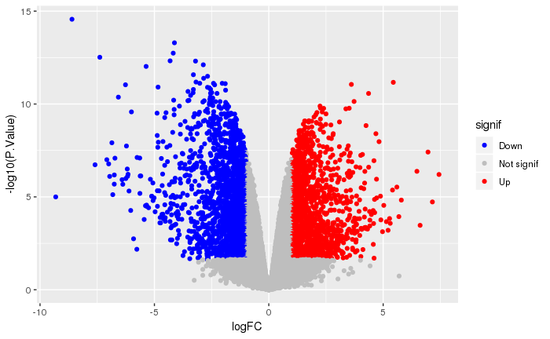

```r
ggplot(de_results, aes(logFC, -log10(P.Value), col=signif)) +
  geom_point() +
  scale_colour_manual(values=c("Up"="red", "Not signif"="grey", "Down"="blue"))
```

## Labelling genes

### Labelling genes of interest

We can label one or more genes of interest in a volcano plot. This enables us to visualize where these genes are in terms of significance and in comparison to the other genes. In the original paper using this dataset, there is a heatmap of 31 genes in Figure 6b. These genes are a set of 30 cytokines/growth factor identified as differentially expressed, and the authors’ main gene of interest, Mcl1. These genes are provided in the volcano genes file and shown below. We will label these genes in the volcano plot. We’ll read in the genes and store it in an object called `goi`.

```r
goi <- read_tsv("/training/r-intro-tidyverse/data/volcano_genes")
```

Let’s take a look at what’s in `goi`

```r
goi
```

| GeneID |
| --- |
| Mcl1 |
| Hbegf |
| Tgfb2 |
| Cxcl16 |
| Csf1 |
| Pdgfb |
| Edn1 |
| Lif |
| Kitl |
| Bmp1 |

[output cut: 21 more lines]

```r
de_results <- mutate(de_results, mygenes=ifelse(SYMBOL %in% goi$GeneID, SYMBOL, ""))
```

Let’s make the volcano plot and label this custom set of genes.

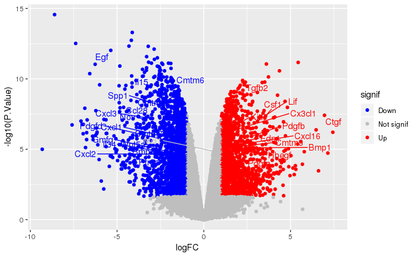

```r
ggplot(de_results, aes(logFC, -log10(P.Value), col=signif)) +
  geom_point() +
  scale_colour_manual(values=c("Up"="red", "Not signif"="grey", "Down"="blue")) +
  geom_text_repel(aes(label=mygenes), show.legend = FALSE)
```

### Labelling top significant genes

We could also label the top significant genes with the gene names so we can see what they are. We have gene symbols in our `de_results` so we could use those.

Let’s label the top 10 most significant genes. To do this we first identify the top 10 genes by P.Value. The file is already sorted by P value and remember head() shows us the top 6 lines in a file. If we look at the help for `head` we see that there is a default argument `n = 6L` we can change this to 10L to get the top 10 lines. We will store this at an object called `top_10`.

```r
top_10 <- head(de_results, n = 10L)
```

Next we’ll add another column to say whether to *label* the point or not using the command below. We’ll call the column labels. We are using ifelse again to say if the value in the SYMBOL column is in the top 10 symbols, add the symbol, otherwise leave the column empty (add “”). Here we see `%in%` being used. This is another very commonly used R function. We use `%in%` when we want to ask if a value is in set of values. In R we also use `$` to refer to columns so `top_10$SYMBOL` means the SYMBOL column of the `top_10` object.

```r
de_results <- mutate(de_results, labels=ifelse(SYMBOL %in% top_10$SYMBOL, SYMBOL, ""))
```

Take a look.

```r
de_results
```

| ENTREZID | SYMBOL | GENENAME | logFC | AveExpr | t | P.Value | adj.P.Val | B | signif | mygenes | labels |
| --- | --- | --- | --- | --- | --- | --- | --- | --- | --- | --- | --- |
| 12992 | Csn1s2b | casein alpha s2-like B | -8.6036111 | 3.56295004 | -46.962400 | 2.732470e-15 | 4.318396e-11 | 24.275762 | Down |  | Csn1s2b |
| 13358 | Slc25a1 | solute carrier family 25 (mitochondrial carrier, citrate transporter), member 1 | -4.1241753 | 5.77969894 | -34.802233 | 5.062272e-14 | 4.000207e-10 | 22.454454 | Down |  | Slc25a1 |
| 20531 | Slc34a2 | solute carrier family 34 (sodium phosphate), member 2 | -4.1778124 | 4.27862904 | -31.437092 | 1.825858e-13 | 9.618621e-10 | 21.296633 | Down |  | Slc34a2 |
| 11941 | Atp2b2 | ATPase, Ca++ transporting, plasma membrane 2 | -7.3869864 | 1.28214315 | -30.189903 | 3.040048e-13 | 1.201123e-09 | 19.573001 | Down |  | Atp2b2 |
| 100705 | Acacb | acetyl-Coenzyme A carboxylase beta | -4.3143199 | 4.44091371 | -29.141192 | 4.743168e-13 | 1.289680e-09 | 20.337203 | Down |  | Acacb |
| 230810 | Slc30a2 | solute carrier family 30 (zinc transporter), member 2 | -3.2031181 | 2.69581148 | -29.067663 | 4.896281e-13 | 1.289680e-09 | 20.286555 | Down |  | Slc30a2 |
| 68801 | Elovl5 | ELOVL family member 5, elongation of long chain fatty acids (yeast) | -2.8633040 | 6.45520453 | -28.031782 | 7.725733e-13 | 1.744250e-09 | 19.945967 | Down |  | Elovl5 |
| 13645 | Egf | epidermal growth factor | -5.3626638 | 0.73590465 | -27.582493 | 9.463856e-13 | 1.869585e-09 | 18.005140 | Down | Egf | Egf |
| 26366 | Ceacam10 | carcinoembryonic antigen-related cell adhesion molecule 10 | -3.2956212 | 1.82101424 | -25.411460 | 2.645520e-12 | 4.645533e-09 | 18.674329 | Down |  | Ceacam10 |
| 68603 | Pmvk | phosphomevalonate kinase | -2.6769833 | 4.72310684 | -25.016839 | 3.218091e-12 | 5.085870e-09 | 18.520052 | Down |  | Pmvk |

[output cut: 990 more lines]

Next we add `+ geom_text()` and add the labels into that. Note we are using `+` again and adding another layer to our plot. This time we are adding a layer of text (labels).

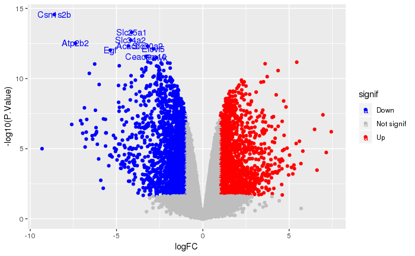

```r
ggplot(de_results, aes(logFC, -log10(P.Value), col=signif)) +
  geom_point() +
  scale_colour_manual(values=c("Up"="red", "Not signif"="grey", "Down"="blue")) +
  geom_text(aes(label=labels))
```

That doesn’t look great as the labels are overlapping but we can fix that. We can replace `+ geom_text()` with `+ geom_text_repel()` from the package **ggrepel**.

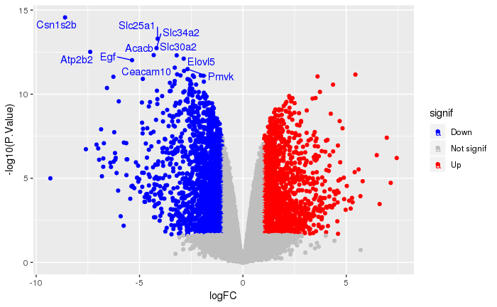

```r
ggplot(de_results, aes(logFC, -log10(P.Value), col=signif)) +
  geom_point() +
  scale_colour_manual(values=c("Up"="red", "Not signif"="grey", "Down"="blue")) +
  geom_text_repel(aes(label=labels))
```

The legend now has a legend for the labels overlapping but we can remove that by adding `show.legend=FALSE`.

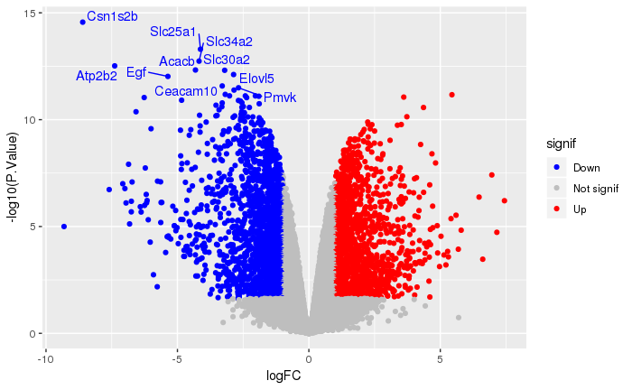

```r
ggplot(de_results, aes(logFC, -log10(P.Value), col=signif)) +
  geom_point() +
  scale_colour_manual(values=c("Up"="red", "Not signif"="grey", "Down"="blue")) +
  geom_text_repel(aes(label=labels), show.legend = FALSE)
```

## Ordering the legend

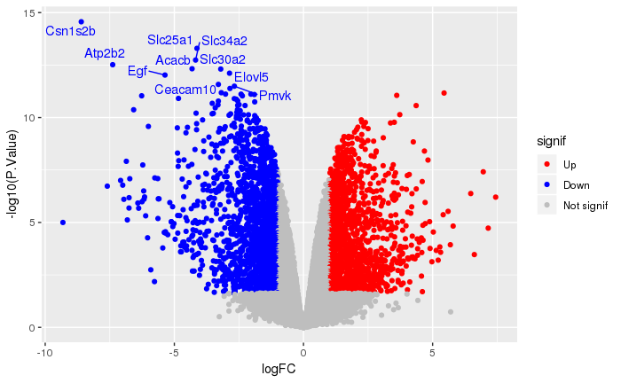

```r
de_results <- mutate(de_results, signif_f=factor(signif, levels=c("Up", "Not signif", "Down")))
ggplot(de_results, aes(logFC, -log10(P.Value), col=signif)) +
  geom_point() +
  scale_colour_manual(values=c("Up"="red", "Not signif"="grey", "Down"="blue"), breaks=c("Up", "Down", "Not signif")) +
  geom_text_repel(aes(label=labels), show.legend = FALSE)
```

## Modifying the plot

If we want, we can just colour the points red and blue, and leave the labels black. We do this by adding the `col=signif` into the `geom_point()` `aes()` instead of in the `ggplot()` `aes()`.

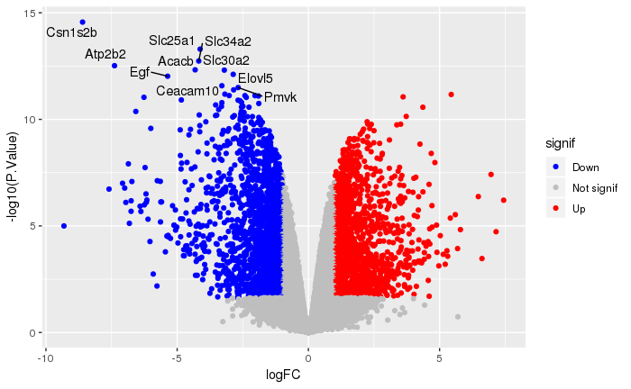

```r
ggplot(de_results, aes(logFC, -log10(P.Value))) +
  geom_point(aes(col=signif)) +
  scale_colour_manual(values=c("Up"="red", "Not signif"="grey", "Down"="blue")) +
  geom_text_repel(aes(label=labels), show.legend = FALSE)
```

We can also make the plot look nicer, for example, adjusting the x axis limits, adding a title and changing the background.

First let’s store our inital plot in an object called `p`, to make it easier to see what we’re changing.

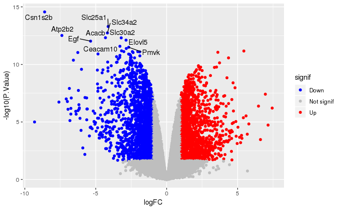

```r
p <- ggplot(de_results, aes(logFC, -log10(P.Value))) +
  geom_point(aes(col=signif)) +
  scale_colour_manual(values=c("Up"="red", "Not signif"="grey", "Down"="blue")) +
  geom_text_repel(aes(label=labels), show.legend = FALSE)
p
```

### Axis limits

We can adjust the x axis so it’s the same limit on the right and left.

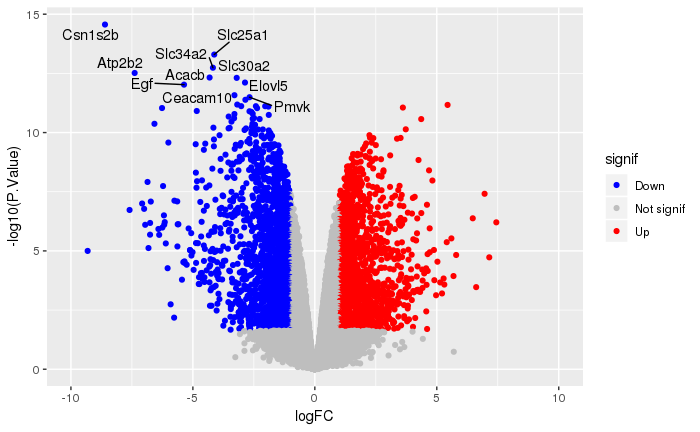

```r
p <- p + scale_x_continuous(limits=c(-10, 10))
p
```

### Title

We can add a title.

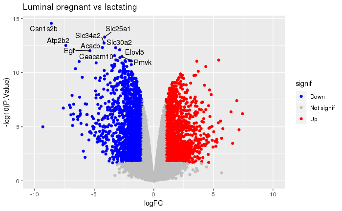

```r
p <- p + labs(title="Luminal pregnant vs lactating")
p
```

### Themes

We can remove the grey background and grid lines. To do this we modify the ggplot theme. Themes are the non-data parts of the plot.

There are also a lot of built-in themes. Let’s have a look at a couple of the more widely used themes. We won’t save these (we won’t use p <-) we’ll just print them to have a look.

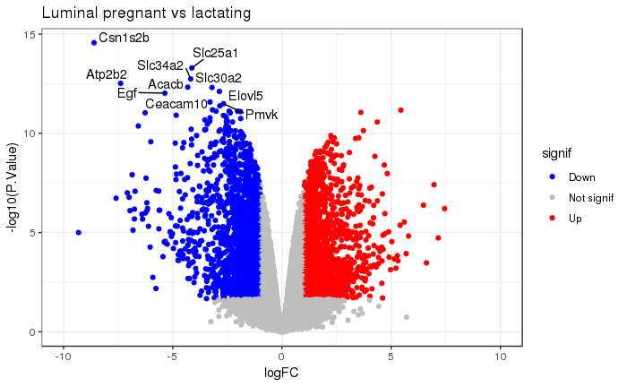

```r
p + theme_bw()
```

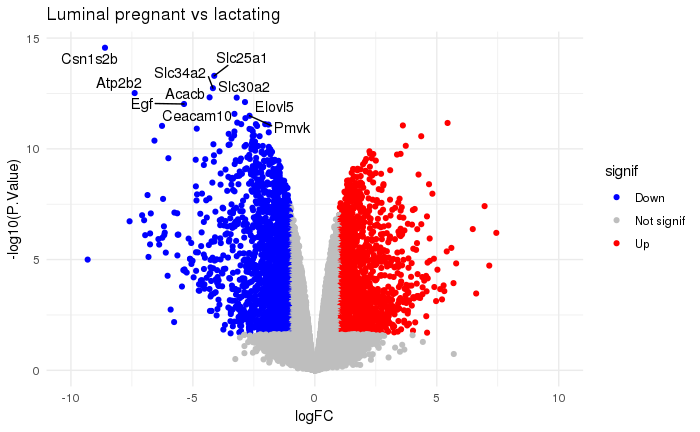

```r
p + theme_minimal()
```

There are many themes available, you can see some in the [R graph gallery](https://www.r-graph-gallery.com/192-ggplot-themes/).

We can also modify parts of the theme individually. We can remove the grey background and grid lines with the code below.

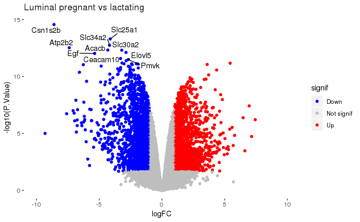

```r
p <- p + theme(panel.background = element_blank(),
               panel.grid.major = element_blank(),
               panel.grid.minor = element_blank())
p
```

We can add axis lines.

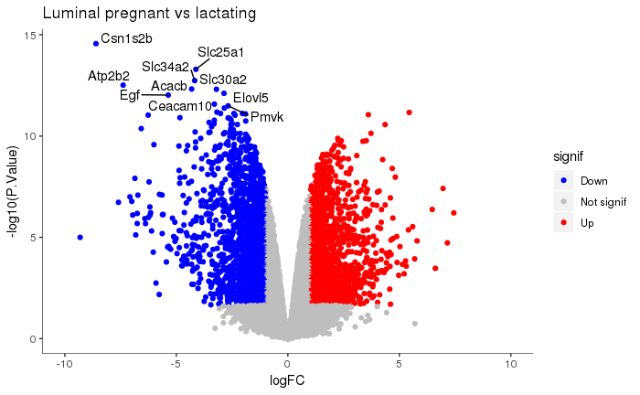

```r
p <- p + theme(axis.line = element_line(size=0.2, colour = "black"))
p
```

We can remove the legend completely.

[figure not shown]

```r
p <- p + theme(legend.position = "none")
p
```

We can centre the title.

[figure not shown]

```r
p <- p + theme(plot.title = element_text(hjust = 0.5))
p
```

#### Exercise

Make a volcano plot for the basal cells using the file “https://zenodo.org/record/2596382/files/limma-voom_basalpregnant-basallactate”. Colour genes with adj.P.value < 0.01 and a logFC of >2 (and < -2). You can choose to use any colours and modify it whatever way you like.

## Key Points

- We can make a volcano plot with `geom_point()` by plotting the log fold change (logFC) vs the negative log10 P value
- We can add columns with dplyr’s mutate
- To highlight or label genes we add a column to specify which genes to colour or label
- We can use ifelse() to test if values meet specified conditions
- We use c() to combine multiple values
- We use %in% to check if a value is in a set of values
- We can use ggrepel to repel overlapping labels
- We use themes to modify the non-data parts of a ggplot